# R Notebook

## Ejercicio 1

**Enumere cuales son las hipótesis que asumimos al hacer una regresión múltiple entre una variable de respuesta y y unas variables predictoras, x1, …, xp.**

- En el modelo de regresión lineal múltiple se supone que la función de regresión que relaciona la variable dependiente con las variables independientes es lineal.
- Asumimos que los errores ε1, ε2, . . . , εn tienen distribución normal de media cero y varianza σ2, y que son independientes.
- Las variables explicativas son linealmente independientes entre si.

## Ejercicio 2

**En un modelo de regresión, como se calcula y como se interpreta el coeficiente de determinación R2.**

El coeficiente de determinación es una medida utilizada para explicar cuánta variabilidad de un factor puede ser causada por su relación con otro factor relacionado.

## Ejercicio 3

**Lea el fichero “BCN_pisos.txt”. Del fichero resultante seleccione 2/3 partes como muestra de training y la tercera parte restante como muestra test.**

```r
pisos_bcn = read.delim("bcn_pisos.txt")
length = nrow(pisos_bcn)
number_training_rows =  round(length / 3) * 2

training = pisos_bcn[0:number_training_rows,]
test = pisos_bcn[number_training_rows:length-1,]
```

## Ejercicio 4

**Con la muestra de training, efectúe la representación gráfica de la variable “Valor” respecto del resto de variables del fichero. Calcule la correlación entre la variable “Valor” y el resto de variables numéricas.**

```r
#install.packages("PerformanceAnalytics")
library(PerformanceAnalytics)
library(quantmod)
```

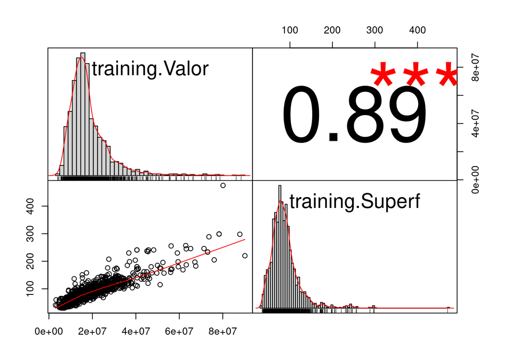

```r
value_vs_super = data.frame(training$Valor, training$Superf)
suppressWarnings(chart.Correlation(value_vs_super))
suppressWarnings(chart.Correlation(value_vs_super))
```

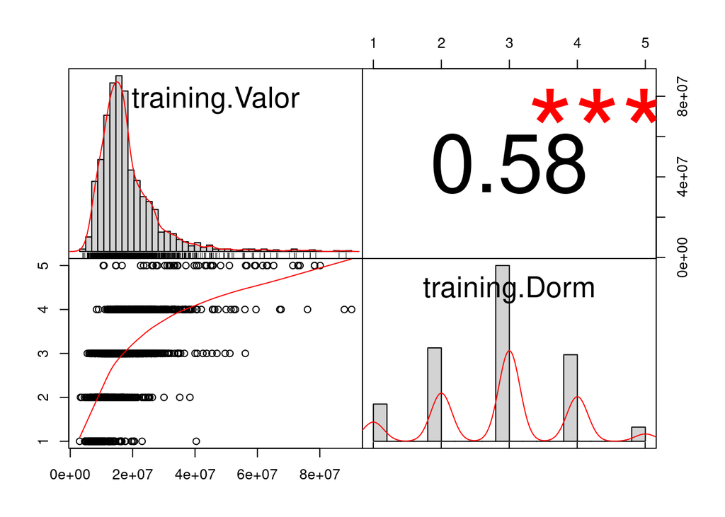

```r
value_vs_dorm = data.frame(training$Valor, training$Dorm)
suppressWarnings(chart.Correlation(value_vs_dorm))
```

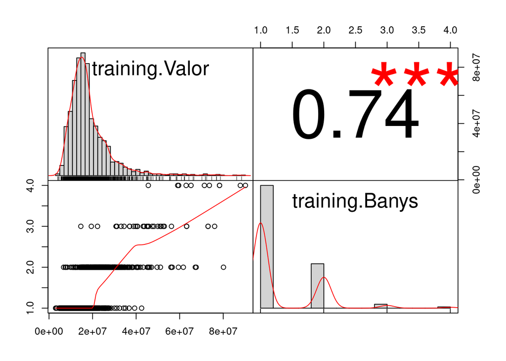

```r
value_vs_banys = data.frame(training$Valor, training$Banys)
suppressWarnings(chart.Correlation(value_vs_banys))
```

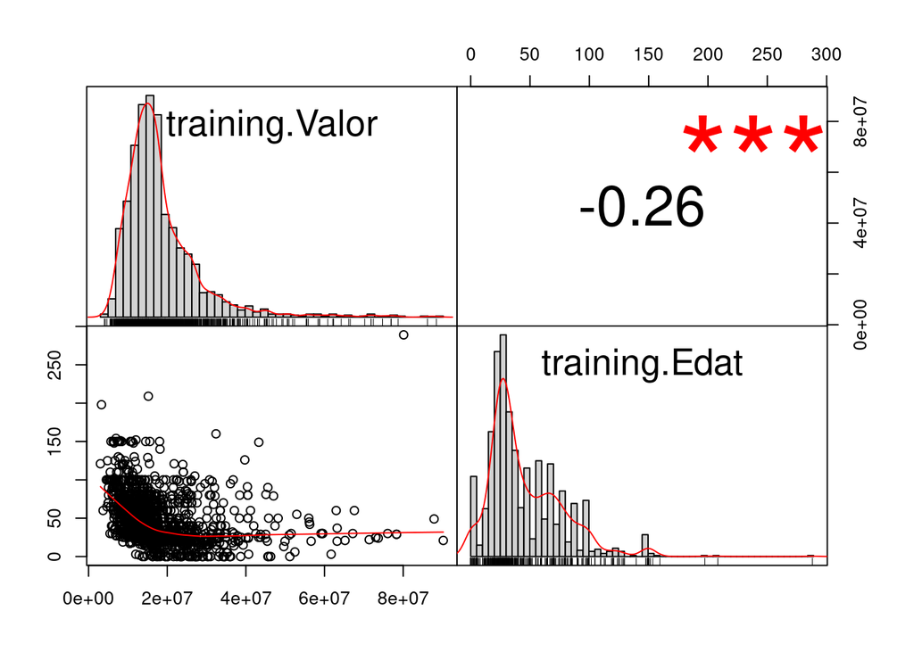

```r
value_vs_edat = data.frame(training$Valor, training$Edat)
suppressWarnings(chart.Correlation(value_vs_edat))
```

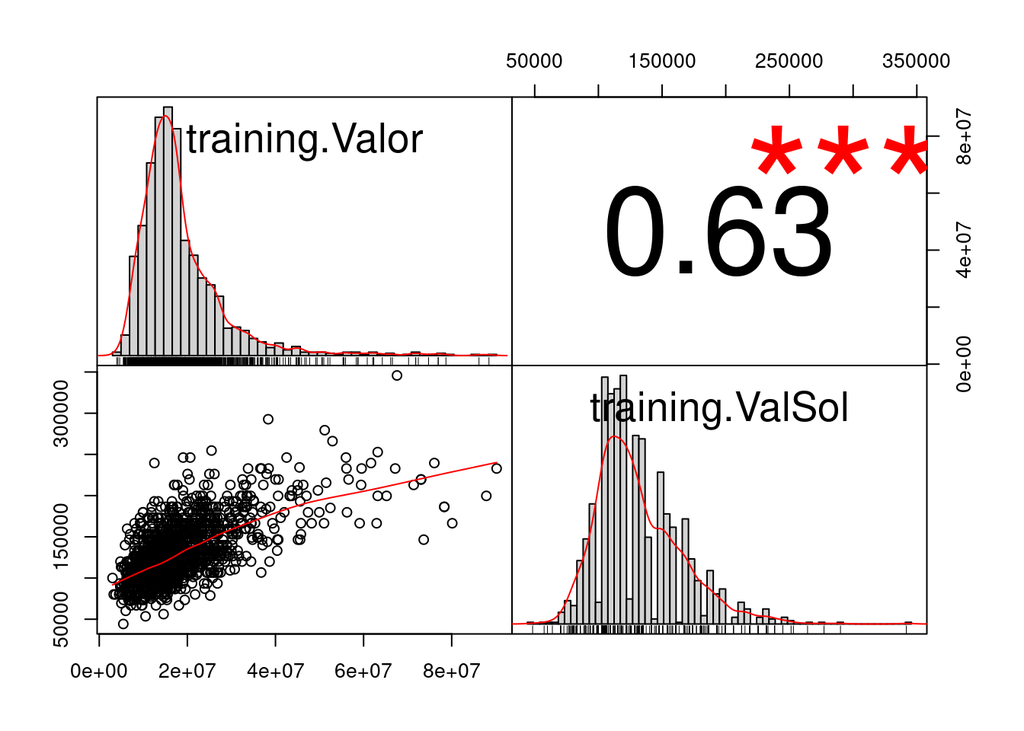

```r
value_vs_valsol= data.frame(training$Valor, training$ValSol)
suppressWarnings(chart.Correlation(value_vs_valsol))
```

Aunque al realizar la representación gráfica, ya hemos visto la **cor** del valor con el resto de las variables ahora realizaremos una tabla de correlaciones.

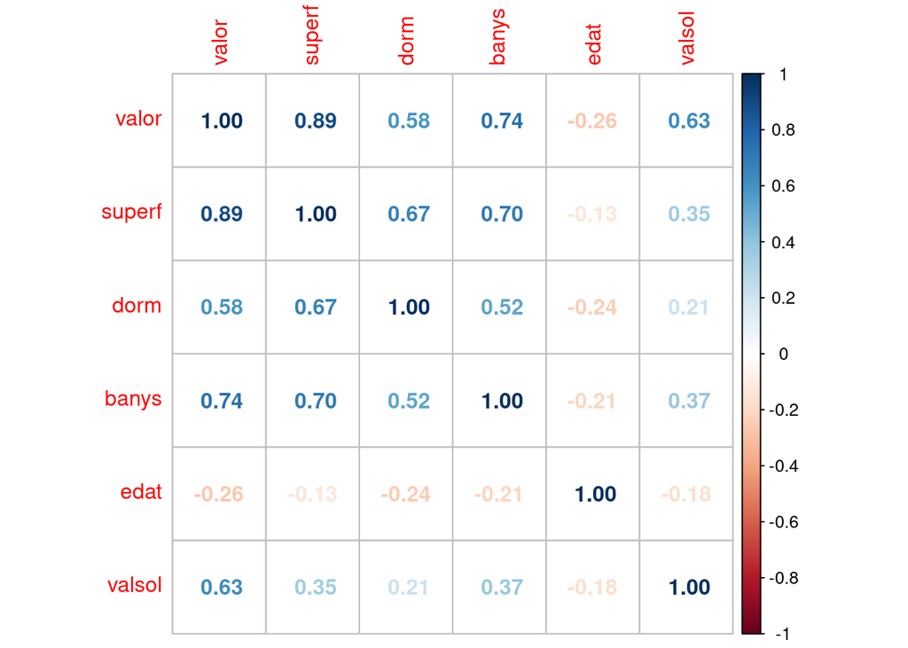

```r
#install.packages('corrplot')
library(corrplot)
df_numeric_variables = data.frame('valor' = training$Valor,
                                  'superf' = training$Superf,
                                  'dorm' = training$Dorm,
                                  'banys' = training$Banys,
                                  'edat' = training$Edat,
                                  'valsol' = training$ValSol)
R = cor(df_numeric_variables)
corrplot(R,method='number')
```

## Ejercicio 5

**Efectúe la regresión simple de la variable “Valor” respecto de la “Superficie”. A continuación añada a la regresión la variable “Número de dormitorios”. Es significativa esta variable una vez que el modelo ya contiene la variable “Superficie”.**

```r
regval_super = lm(training$Valor ~ training$Superf, training)
regval_super_dorm = lm(training$Valor ~ training$Super + training$Dorm, training)
summary = summary(regval_super_dorm)
anova = anova(regval_super_dorm)
summary
```

```
##
## Call:
## lm(formula = training$Valor ~ training$Super + training$Dorm,
##     data = training)
##
## Residuals:
##       Min        1Q    Median        3Q       Max
## -39576915  -2204364   -325563   1906411  37065352
##
## Coefficients:
##                Estimate Std. Error t value Pr(>|t|)
## (Intercept)    -3477186     375265  -9.266   <2e-16 ***
## training$Super   261684       4483  58.367   <2e-16 ***
## training$Dorm   -239684     164233  -1.459    0.145
## ---
## Signif. codes:  0 '***' 0.001 '**' 0.01 '*' 0.05 '.' 0.1 ' ' 1
##
## Residual standard error: 4642000 on 1549 degrees of freedom
## Multiple R-squared:  0.7936, Adjusted R-squared:  0.7933
## F-statistic:  2977 on 2 and 1549 DF,  p-value: < 2.2e-16
```

```r
anova
```

|  | Df | Sum Sq | Mean Sq | F value | Pr(>F) |
| --- | --- | --- | --- | --- | --- |
| training$Super | 1 | 1.282614e+17 | 1.282614e+17 | 5952.322887 | 0.0000000 |
| training$Dorm | 1 | 4.589541e+13 | 4.589541e+13 | 2.129902 | 0.1446527 |
| Residuals | 1549 | 3.337805e+16 | 2.154813e+13 | NA | NA |

**Summary:**

Podemos observar que la variable Dorm tiene un valor muy negativo -239684, además el p-value es de 0.145, por tanto podemos deducir que no, no es una variable significativa.

**Anova:**

Realizando el test anova confirma lo que habiamos dicho, con un p_value de 0.1447 podemos decir que la variable no es significante.

**El -239684 quiere decir que pagamos -239684 pesetas por piso???l**

## Ejercicio 6

**Efectúe la regresión múltiple del “Valor” respecto el resto de variables del fichero “BCN_pisos”.¿Le parece que alguna variable predictora es no significativa?.**

```r
reg = lm(training$Valor~.,training)
setepval = step(reg)
```

```
## Start:  AIC=45690.87
## training$Valor ~ Superf + Dorm + Banys + Edat + Estat + Planta +
##     Dist + ValSol + Tipus + Ascens + ExtInt + Reforma
##
##           Df  Sum of Sq        RSS   AIC
## - Ascens   1 1.0632e+12 9.0920e+15 45689
## - Dorm     1 9.5189e+12 9.1005e+15 45690
## <none>                  9.0910e+15 45691
## - Planta   2 4.9658e+13 9.1406e+15 45695
## - ExtInt   1 5.2515e+13 9.1435e+15 45698
## - Tipus    1 1.2553e+14 9.2165e+15 45710
## - Reforma  8 2.7561e+14 9.3666e+15 45721
## - Edat     1 2.0539e+14 9.2963e+15 45724
## - Dist     9 4.1350e+14 9.5045e+15 45742
## - Banys    1 5.9611e+14 9.6871e+15 45787
## - Estat    4 9.7273e+14 1.0064e+16 45841
## - ValSol   1 7.7456e+15 1.6837e+16 46645
## - Superf   1 2.7369e+16 3.6460e+16 47845
##
## Step:  AIC=45689.05
## training$Valor ~ Superf + Dorm + Banys + Edat + Estat + Planta +
##     Dist + ValSol + Tipus + ExtInt + Reforma
##
##           Df  Sum of Sq        RSS   AIC
## - Dorm     1 9.6506e+12 9.1017e+15 45689
## <none>                  9.0920e+15 45689
## - Planta   2 4.9647e+13 9.1417e+15 45694
## - ExtInt   1 5.1472e+13 9.1435e+15 45696
## - Tipus    1 1.2460e+14 9.2166e+15 45708
## - Reforma  8 2.7775e+14 9.3698e+15 45720
## - Edat     1 2.2701e+14 9.3190e+15 45725
## - Dist     9 4.1481e+14 9.5068e+15 45740
## - Banys    1 5.9679e+14 9.6888e+15 45786
## - Estat    4 9.7368e+14 1.0066e+16 45839
## - ValSol   1 7.7992e+15 1.6891e+16 46648
## - Superf   1 2.8250e+16 3.7342e+16 47880
##
## Step:  AIC=45688.7
## training$Valor ~ Superf + Banys + Edat + Estat + Planta + Dist +
##     ValSol + Tipus + ExtInt + Reforma
##
##           Df  Sum of Sq        RSS   AIC
## <none>                  9.1017e+15 45689
## - Planta   2 5.2908e+13 9.1546e+15 45694
## - ExtInt   1 5.4905e+13 9.1566e+15 45696
## - Tipus    1 1.2809e+14 9.2298e+15 45708
## - Reforma  8 2.7379e+14 9.3755e+15 45719
## - Edat     1 2.1746e+14 9.3191e+15 45723
## - Dist     9 4.3639e+14 9.5381e+15 45743
## - Banys    1 5.8719e+14 9.6889e+15 45784
## - Estat    4 1.0128e+15 1.0114e+16 45844
## - ValSol   1 7.8394e+15 1.6941e+16 46651
## - Superf   1 3.6450e+16 4.5552e+16 48186
```

```r
setepval
```

```
##
## Call:
## lm(formula = training$Valor ~ Superf + Banys + Edat + Estat +
##     Planta + Dist + ValSol + Tipus + ExtInt + Reforma, data = training)
##
## Coefficients:
##       (Intercept)             Superf              Banys               Edat
##        -1.212e+07          2.010e+05          1.660e+06         -1.764e+04
##          Estat2_M           Estat3_N           Estat4_B          Estat5_MB
##         1.260e+06          2.195e+06          3.356e+06          2.722e+06
##       PlantaBajos       PlantaPlanta       DistEixample         DistGracia
##        -8.365e+05         -5.864e+05         -9.225e+05         -1.105e+06
##         DistHorta      DistLes_Corts     DistNou_Barris    DistSant_Andreu
##        -1.235e+06          2.162e+05         -8.132e+05         -8.977e+05
##    DistSant_Marti          DistSants         DistSarria             ValSol
##        -1.077e+06         -8.813e+05          8.977e+05          9.296e+01
##         TipusMANZ          ExtIntINT   ReformaOBRANUEVA   ReformaRECIENREF
##        -1.175e+06          5.564e+05          2.709e+06          1.685e+05
##     ReformaREF>20    ReformaREF10-15    ReformaREF15-20      ReformaREF1A5
##         2.933e+05          1.704e+05          1.814e+05          3.237e+05
##    ReformaREF5A10  ReformaSINREFORMA
##         4.627e+05         -4.537e+05
```

Podemos observar que ya no tenemos las 12 variables predictoras iniciales y que tenemos 10, el menor AIC:

- AIC es 45688.7

Con las variables:

- Superf + Banys + Edat + Estat + Planta + Dist + ValSol + Tipus + ExtInt + Reforma

Las variables predictoras que no son significativas son:

- Dorm
- Ascens

## Ejercicio 7

**Encuentre la regresión óptima. ¿Cuál es el valor del R2 alcanzado?. ¿Y cuál el valor del R2 por validación cruzada “leave one out”?**

```r
pred <- predict(reg, training)
predSSE <- sum((training$Valor-pred)^2)
R2test <- 1 - predSSE/(var(training$Valor)*(nrow(training)-1))
"R"
```

```
## [1] "R"
```

```r
R2test
```

```
## [1] 0.9437738
```

```r
PRESS <- sum((reg$residuals/(1-ls.diag(reg)$hat))^2)
R2loo = 1 - PRESS/(var(training$Valor)*(nrow(training)-1))
"LOO"
```

```
## [1] "LOO"
```

```r
R2loo
```

```
## [1] 0.9397072
```

Podemos observar que el valor para LOO es algo inferior, aún así este valor es más honesto.

## Ejercicio 8

**Realice el análisis de los residuos. ¿Son normales los residuos?, ¿Existe alguna relación de dependencia con los valores ajustados?. ¿Existe heterocedasticidad?. ¿Existen observaciones influyentes?**

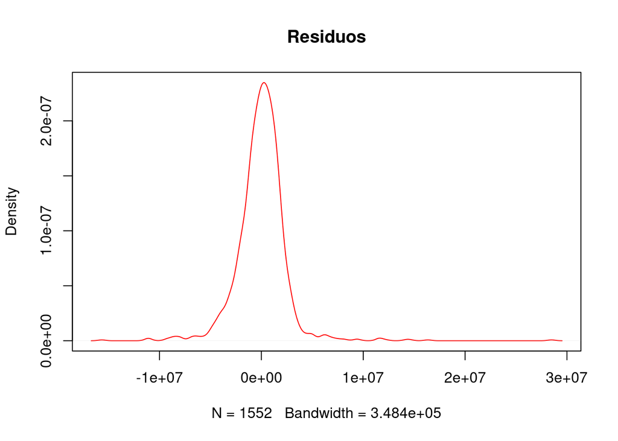

```r
# Residuos
plot(density(reg$residuals),col="red", main="Residuos")
```

```r
# TEST heterocedasticidad
library(lmtest)
bptest(reg)
```

```
##
##  studentized Breusch-Pagan test
##
## data:  reg
## BP = 342.9, df = 31, p-value < 2.2e-16
```

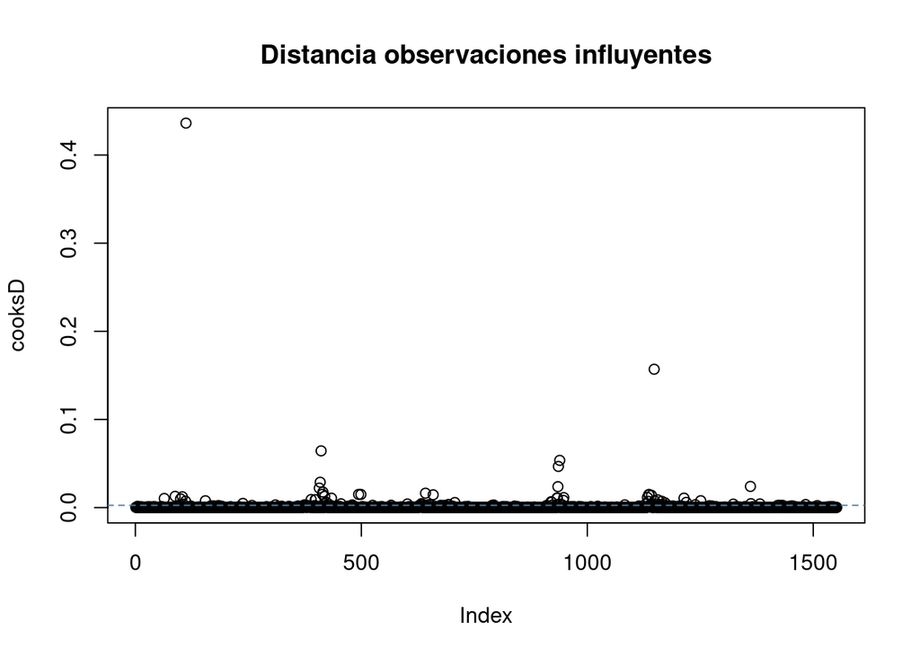

```r
# Valores influyentes
cooksD <- cooks.distance(reg)
n <- nrow(training)
umbral =  4
plot(cooksD, main = "Distancia observaciones influyentes")
abline(h = umbral / n, lty = 2, col = "steelblue")
```

```r
influential_obs <- as.numeric(cooksD[(cooksD>(4 / n))])
influential_obs
```

```
##  [1] 0.010348212 0.012773649 0.009885927 0.003014155 0.012300314 0.003898346
##  [7] 0.007277517 0.436183458 0.007749997 0.004746485 0.003052355 0.003102953
## [13] 0.002907174 0.009198896 0.009013290 0.009013290 0.022119365 0.028775524
## [19] 0.064365643 0.015081890 0.017616648 0.012851985 0.006066122 0.002635455
## [25] 0.004137163 0.010695205 0.004288933 0.003052282 0.014911718 0.014911718
## [31] 0.002587294 0.002701008 0.004076472 0.004445637 0.003882347 0.002857441
## [37] 0.016349058 0.002966199 0.003364130 0.003364130 0.014521131 0.002632008
## [43] 0.002608929 0.003551698 0.005743127 0.002628765 0.002978249 0.006661747
## [49] 0.006148448 0.002848494 0.003219419 0.010840725 0.010840725 0.023751810
## [55] 0.046702624 0.004054275 0.053570978 0.003703734 0.003278485 0.008213382
## [61] 0.011310715 0.003103325 0.003981566 0.011569361 0.007088013 0.014766679
## [67] 0.014766679 0.002663453 0.013891034 0.156975435 0.007677306 0.003816140
## [73] 0.008783091 0.003285187 0.007127794 0.003465911 0.005397145 0.010732366
## [79] 0.005965145 0.003257253 0.007803225 0.003922858 0.024003772 0.004453533
## [85] 0.004144553 0.002581521 0.002581521 0.003456955
```

**Quiza habría que subir el umbral**

**REVISAR == faltan: dependencia con los valores ajustados**

## Ejercicio 9

**Obtenga el valor del R2 de predicción en la muestra test.**

```r
pred <- predict(reg, test)
predSSE <- sum((test$Valor-pred)^2)
R2test <- 1 - predSSE/(var(test$Valor)*(nrow(test)-1))
R2test
```

```
## [1] 0.9413005
```

## Ejercicio 10

**Obtenga el fichero con las predicciones del valor de las viviendas con su intervalo de confianza del 95%, para los pisos de la muestra test.**

```r
pred_conf <- predict(reg, newdata=test, interval="confidence")
pred_conf
```

```
##           fit      lwr      upr
## 1551 28925135 27793058 30057212
## 1552 10115547  9505246 10725849
## 1553 10039551  8998165 11080937
## 1554 16470184 15701641 17238727
## 1555 12104003 11500724 12707283
## 1556 17955868 17301426 18610310
## 1557 19289499 18144580 20434419
## 1558 26383079 25244493 27521665
## 1559 19835344 18886538 20784149
## 1560 22695180 22097313 23293046
## 1561 18845789 18295446 19396132
## 1562 11482529 10825965 12139093
## 1563 27222591 26693101 27752080
## 1564 16709673 15995159 17424188
```

[output cut: 764 more lines]